# Relatório

```python
import pandas as pd
import datetime as dt
import matplotlib.pyplot as plt
from matplotlib.dates import date2num
import numpy as np

from matplotlib.finance import candlestick_ochl
from matplotlib import style
from math import log

style.use('ggplot')
%matplotlib inline
```

## Ativos

Quero analisar três ativos diferentes: cemig, usiminas e a embraer. Uma vez que foram escolhidos, começarei a estudá-los.

```python
cemig_data = pd.read_csv('CMIG4.csv',delimiter=';')
usiminas_data = pd.read_csv('USIM5.csv', delimiter=';')
embraer_data = pd.read_csv('EMBR3.csv', delimiter=';')
```

## Cemig

```python
cemig_normalizado = group_by_day(cemig_data)
```

### Últimos dias

```python
#primeiro dia: 20080102, ultimo dia 20160512
cemig_normalizado.tail()
```

| datahora | abertura | fechamento | maximo | minimo | negocios | quantidade_papeis | volume_financeiro | fechamento_anterior | retorno | subiu | dia | datahora | ema | sma | rsf |
| --- | --- | --- | --- | --- | --- | --- | --- | --- | --- | --- | --- | --- | --- | --- | --- |
| 2016-05-06 | 1.788421 | 1.806648 | 1.832581 | 1.773256 | 9.052282 | 15.642959 | 17.452729 | 1.824549 | -0.017901 | -1 | 2049 | 2016-05-06 | 1.838616 | 1.853081 | 24.118724 |
| 2016-05-09 | 1.822935 | 1.830980 | 1.834180 | 1.761300 | 9.447860 | 15.635744 | 17.426037 | 1.806648 | 0.024332 | 1 | 2050 | 2016-05-09 | 1.832408 | 1.843996 | 22.242656 |
| 2016-05-10 | 1.811562 | 1.785070 | 1.862529 | 1.801710 | 9.882162 | 15.979626 | 17.812668 | 1.830980 | -0.045910 | -1 | 2051 | 2016-05-10 | 1.812568 | 1.818510 | 22.088905 |
| 2016-05-11 | 1.871802 | 1.862529 | 1.900614 | 1.845300 | 9.560645 | 15.804740 | 17.677674 | 1.785070 | 0.077458 | 1 | 2052 | 2016-05-11 | 1.826043 | 1.821955 | 37.405651 |
| 2016-05-12 | 1.871802 | 1.856298 | 1.931521 | 1.864080 | 10.094315 | 16.229038 | 18.129574 | 1.862529 | -0.006231 | -1 | 2053 | 2016-05-12 | 1.837376 | 1.828305 | 37.879335 |

### Visualizações

Tirei log de praticamennte tudo, como foi sugerido.

No gráfico subidas e descidas, eu comparo se o preço de hoje subiu (valor 1), desceu (valor -1) ou não mudou (valor 0) em comparação com o valor anterior.

#### Toda a série temporal:

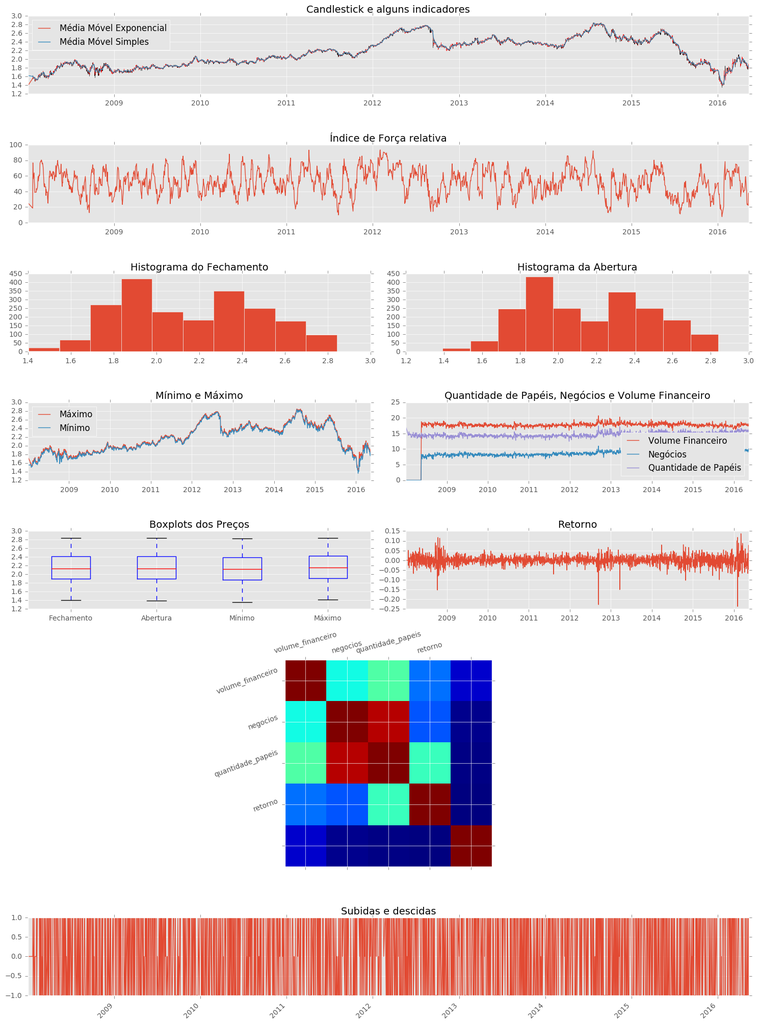

```python
dataframe_visualizations(cemig_normalizado, '20080102','20160512')
```

#### Últimos 6 meses

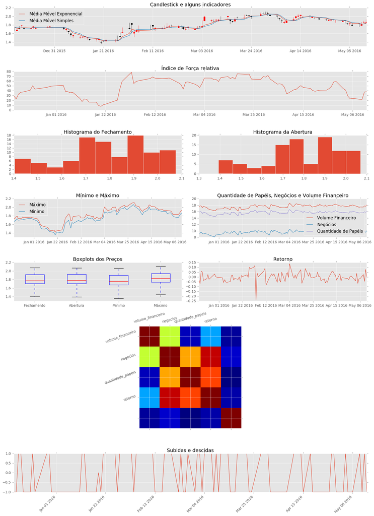

```python
dataframe_visualizations(cemig_normalizado, '20151212','20160512')
```

## Embraer

```python
embraer_normalizado = group_by_day(embraer_data)
```

### Últimos dias

```python
embraer_normalizado.tail()
```

| datahora | abertura | fechamento | maximo | minimo | negocios | quantidade_papeis | volume_financeiro | fechamento_anterior | retorno | subiu | dia | datahora | ema | sma | rsf |
| --- | --- | --- | --- | --- | --- | --- | --- | --- | --- | --- | --- | --- | --- | --- | --- |
| 2016-05-06 | 2.991222 | 2.991222 | 3.002708 | 2.952303 | 8.674539 | 14.692229 | 17.658053 | 3.002211 | -0.010989 | -1 | 2049 | 2016-05-06 | 2.999880 | 3.000808 | 24.958342 |
| 2016-05-09 | 2.950735 | 2.954910 | 2.990720 | 2.943386 | 9.369564 | 15.023127 | 17.991705 | 2.991222 | -0.036312 | -1 | 2050 | 2016-05-09 | 2.983891 | 2.991050 | 13.237161 |
| 2016-05-10 | 2.971440 | 2.971952 | 2.985177 | 2.954910 | 9.258178 | 14.938490 | 17.914349 | 2.954910 | 0.017041 | 1 | 2051 | 2016-05-10 | 2.977638 | 2.984700 | 20.146915 |
| 2016-05-11 | 2.989211 | 2.982647 | 2.997730 | 2.953868 | 9.051462 | 14.424841 | 17.391690 | 2.971952 | 0.010695 | 1 | 2052 | 2016-05-11 | 2.977637 | 2.980588 | 26.598385 |
| 2016-05-12 | 2.952825 | 2.956472 | 2.968875 | 2.931194 | 9.176680 | 14.787652 | 17.733056 | 2.982647 | -0.026175 | -1 | 2053 | 2016-05-12 | 2.969503 | 2.971441 | 22.685221 |

### Visualizações

#### Toda a série temporal

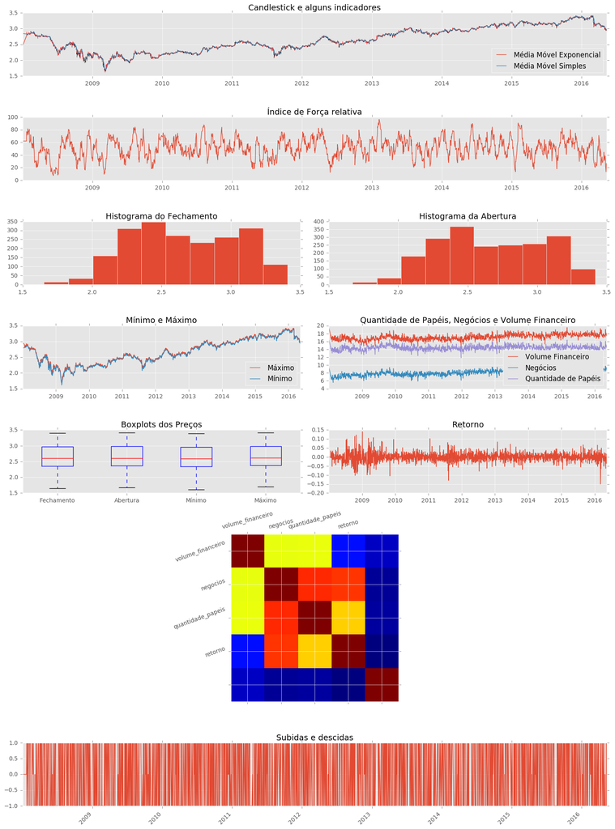

```python
dataframe_visualizations(embraer_normalizado, '20080102','20160512')
```

#### Últimos 6 meses

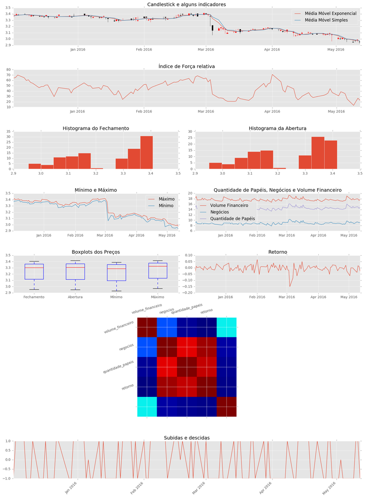

```python
dataframe_visualizations(embraer_normalizado, '20151202','20160512')
```

## Usiminas

```python
usiminas_normalizado = group_by_day(usiminas_data)
```

#### Últimos dias

```python
usiminas_normalizado.tail()
```

| datahora | abertura | fechamento | maximo | minimo | negocios | quantidade_papeis | volume_financeiro | fechamento_anterior | retorno | subiu | dia | datahora | ema | sma | rsf |
| --- | --- | --- | --- | --- | --- | --- | --- | --- | --- | --- | --- | --- | --- | --- | --- |
| 2016-05-06 | 0.824175 | 0.845868 | 0.879627 | 0.824175 | 9.169310 | 17.088522 | 17.936604 | 0.887891 | -0.042023 | -1 | 2049 | 2016-05-06 | 0.868537 | 0.877436 | 60.170687 |
| 2016-05-09 | 0.806476 | 0.845868 | 0.819780 | 0.703098 | 9.494842 | 17.443780 | 18.212081 | 0.845868 | 0.000000 | 0 | 2050 | 2016-05-09 | 0.857641 | 0.863351 | 56.819440 |
| 2016-05-10 | 0.797507 | 0.765468 | 0.858662 | 0.783902 | 9.514437 | 17.246927 | 18.057968 | 0.845868 | -0.080400 | -1 | 2051 | 2016-05-10 | 0.823916 | 0.835601 | 52.531140 |
| 2016-05-11 | 0.875469 | 0.858662 | 0.900161 | 0.841567 | 9.359450 | 17.477098 | 18.351966 | 0.765468 | 0.093194 | 1 | 2052 | 2016-05-11 | 0.832142 | 0.840751 | 51.461615 |
| 2016-05-12 | 0.879627 | 0.858662 | 0.896088 | 0.824175 | 9.188708 | 17.061601 | 17.922072 | 0.858662 | 0.000000 | 0 | 2053 | 2016-05-12 | 0.839257 | 0.834906 | 44.919177 |

### Visualizações

#### Toda a série temporal

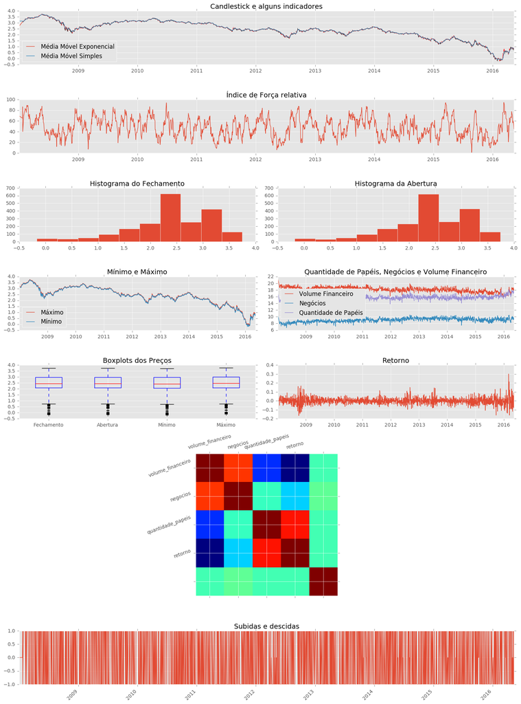

```python
dataframe_visualizations(usiminas_normalizado, '20080102','20160512')
```

#### Últimos 6 meses

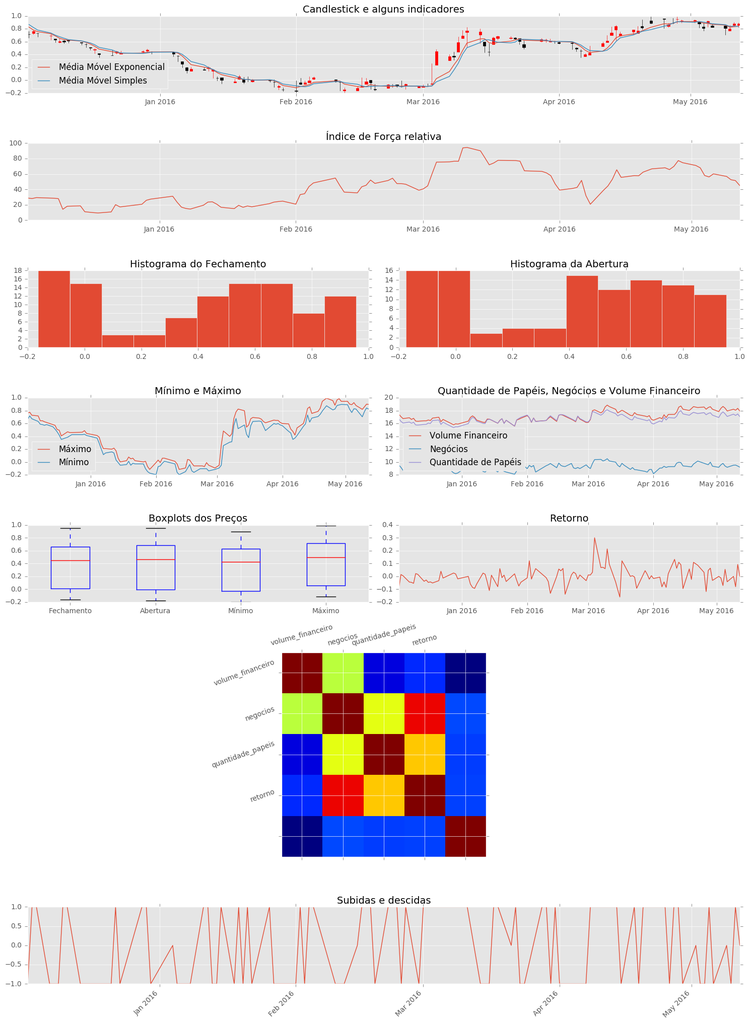

```python
dataframe_visualizations(usiminas_normalizado, '20151202','20160512')
```

## Funções auxiliares:

A função **group_by_day()** recebe um dataframe de um dos ativos compartilhados pelo professor, com granularidade de 15 a 15 minutos e transforma em um dataframe com granularidade diária, pegando os valores máximos e mínimos de cada atributo, calculando também o retorno. Tudo em em escala logaritmica.

```python
def group_by_day(dataframe):
    dados = {'abertura': 0, 'minimo': 0, 'maximo': 0, 'fechamento_anterior': 0, 'negocios': 0,
             'quantidade_papeis': 0, 'volume_financeiro': 0, 'datahora': 0, 'dia': 0,
             'retorno': 0, 'fechamento': 0, 'subiu': 0, 'ema': 0, 'sma': 0, 'rsf': 0}
    dia_atual = None
    todos_dados = []
    ultimo_fechamento = 0
    janela_medias = 5
    janela_ifr = 14
    janela_dados = []
    for d in dataframe.iterrows():

        if not dia_atual:
            dia_atual = str(d[1][9])[6:8]

            dados['fechamento'], dados['abertura'], dados['maximo'], dados['minimo'] = d[1][1], d[1][2], d[1][3], d[1][4]
            dados['fechamento_anterior'], dados['negocios'], dados['quantidade_papeis'], dados['volume_financeiro'] = d[1][5], d[1][6], d[1][7], d[1][8]
            dados['datahora'], dados['dia'], dados['retorno'], dados['subiu'] = dt.datetime.strptime(str(d[1][9])[0:8], '%Y%m%d'), len(todos_dados), 0, 0

        elif  dia_atual != str(d[1][9])[6:8]:
            if len(janela_dados) >= janela_ifr - 1:
                dados['dia'] = len(todos_dados)
                if len(todos_dados) > 0:
                    dados['fechamento'] = ultimo_fechamento
                    dados['fechamento_anterior'] = todos_dados[len(todos_dados) - 1][1]
                    dados['retorno'] = log(dados['fechamento']) - dados['fechamento_anterior']
                    janela_dados.append([log(dados['fechamento']), dados['retorno']])

                    #Olhando se o preço subiu, desceu ou ficou neutro comparado com anteriormente:
                    if log(dados['fechamento']) < dados['fechamento_anterior']:
                        dados['subiu'] = -1
                    elif log(dados['fechamento']) > dados['fechamento_anterior']:
                        dados['subiu'] = 1
                    else:
                        dados['subiu'] = 0

                else:
                    dados['fechamento'] = fechamento_atual
                    janela_dados.append([log(dados['fechamento']), log(fechamento_atual) - log(fechamento_anterior)])

                dados['ema'] = exponencial_moving_average(janela_dados[janela_ifr - janela_medias : janela_ifr], janela_medias, dados['ema'])
                dados['sma'] = simple_moving_average(janela_dados[janela_ifr - janela_medias : janela_ifr], janela_medias)
                dados['rsf'] = relative_strength_index(janela_dados, janela_ifr)

                aux0 = [dados['abertura'], dados['fechamento'], dados['maximo'], dados['minimo'],
                       dados['negocios'], dados['quantidade_papeis'], dados['volume_financeiro'],
                       dados['fechamento_anterior'], dados['retorno'], dados['subiu'], dados['dia'],  dados['datahora'],
                       dados['ema'], dados['sma'], dados['rsf']]

                aux1 = list(map(lambda x: 1 if x == 0 else x, aux0[:7])) + aux0[7:]

                todos_dados.append(list(map(log, aux1[:7])) + aux1[7:])
                #todos_dados.append(aux0)

                ultimo_fechamento = fechamento_atual

                dados['fechamento'], dados['abertura'], dados['maximo'], dados['minimo'] = d[1][1], d[1][2], d[1][3], d[1][4]
                dados['negocios'], dados['quantidade_papeis'], dados['volume_financeiro'] = d[1][6], d[1][7], d[1][8]
                dados['datahora'], dados['retorno'], dados['subiu'] = dt.datetime.strptime(str(d[1][9])[0:8], '%Y%m%d'), 0, 0
                janela_dados.pop(0)
            else:
                pos = lambda x: 1 if x == 0 else x
                janela_dados.append([log(fechamento_atual), log(fechamento_atual) - log(fechamento_anterior)])

        if dados['minimo'] > d[1][4]: dados['minimo'] = d[1][4]
        if dados['maximo'] < d[1][3]: dados['maximo'] = d[1][3]

        dados['negocios'] += d[1][6]
        dados['quantidade_papeis'] += d[1][7]
        dados['volume_financeiro'] += d[1][8]

        dia_atual = str(d[1][9])[6:8]
        fechamento_atual = d[1][1]
        fechamento_anterior = d[1][5]

    new_df = pd.DataFrame(todos_dados, columns=['abertura', 'fechamento', 'maximo', 'minimo','negocios',
                                                'quantidade_papeis', 'volume_financeiro','fechamento_anterior',
                                               'retorno', 'subiu', 'dia', 'datahora', 'ema', 'sma', 'rsf'])
    new_df.index = new_df['datahora']
    del(todos_dados)
    return new_df
```

A função **dataframe_visualizations** mostra os gráficos dos principais atributos de cada ativo, em um dado intervalo de tempo.

```python
def dataframe_visualizations(dataframe, initial_time, final_time):
    temp = dataframe.loc[initial_time : final_time]
    fontsize = 14
    quotes = []
    for i in temp.iterrows():
        quotes.append((date2num(i[1][11]), i[1][0], i[1][1], i[1][2], i[1][3]))

    num_col = 6
    num_lin = 8

    fig = plt.figure(figsize=(15, 20))
    main = plt.subplot2grid((num_lin,num_col),(0, 0),rowspan=1, colspan=num_col)
    candlestick_ochl(main, quotes, width=0.6)

    main.set_title('Candlestick e alguns indicadores', fontsize=fontsize)
    main.plot(temp['datahora'], temp['ema'], label='Média Móvel Exponencial')
    main.plot(temp['datahora'], temp['sma'], label='Média Móvel Simples')
    main.xaxis_date()
    main.legend(prop={'size':fontsize - 2}, loc="best")

    rel = plt.subplot2grid((num_lin,num_col),(1, 0),rowspan=1, colspan=num_col)
    rel.set_title('Índice de Força relativa', fontsize=fontsize)
    rel.plot(temp['datahora'], temp['rsf'], label='Índice de Força Relativa')

    hist_close = plt.subplot2grid((num_lin, num_col), (2,0), rowspan=1, colspan=3)
    hist_close.hist(x=temp['fechamento'])
    hist_close.set_title('Histograma do Fechamento', fontsize=fontsize)

    hist_open = plt.subplot2grid((num_lin, num_col), (2,3), rowspan=1, colspan=3)
    hist_open.hist(x=temp['abertura'])
    hist_open.set_title('Histograma da Abertura', fontsize=fontsize)

    max_min = plt.subplot2grid((num_lin, num_col), (3,0), rowspan=1, colspan=3)
    max_min.plot(temp['datahora'],temp['maximo'], label='Máximo')
    max_min.plot(temp['datahora'],temp['minimo'], label='Mínimo')
    max_min.set_title('Mínimo e Máximo', fontsize=fontsize)
    max_min.legend(prop={'size':fontsize - 2}, loc="best")

    qnt = plt.subplot2grid((num_lin, num_col), (3,3), rowspan=1, colspan=3)
    qnt.plot(temp['datahora'],temp['volume_financeiro'], label='Volume Financeiro')
    qnt.plot(temp['datahora'],temp['negocios'], label='Negócios')
    qnt.plot(temp['datahora'],temp['quantidade_papeis'], label='Quantidade de Papéis')
    qnt.set_title('Quantidade de Papéis, Negócios e Volume Financeiro', fontsize=fontsize)
    qnt.legend(prop={'size':fontsize - 2}, loc="best")

    boxplot = plt.subplot2grid((num_lin, num_col), (4, 0), rowspan=1, colspan=3)
    boxplot.boxplot(x=[temp['fechamento'], temp['abertura'], temp['minimo'], temp['maximo']],
                      labels=['Fechamento', 'Abertura', 'Mínimo', 'Máximo'])
    boxplot.set_title('Boxplots dos Preços', fontsize=fontsize)

    retorno = plt.subplot2grid((num_lin, num_col), (4, 3), rowspan=1, colspan=3)
    retorno.plot(temp['datahora'],temp['retorno'])
    retorno.set_title('Retorno', fontsize=fontsize)

    corr = temp[['fechamento', 'volume_financeiro', 'negocios', 'quantidade_papeis', 'retorno']].corr()

    coor_fig =plt.subplot2grid((num_lin, num_col), (5, 0), rowspan=2, colspan=6)
    coor_fig.matshow(corr)
    coor_fig.set_xticklabels(corr.columns, rotation=15)
    coor_fig.set_yticklabels(corr.columns, rotation=20)

    osc = plt.subplot2grid((num_lin, num_col), (7, 0), rowspan=1, colspan=6)
    osc.plot(temp['datahora'],temp[['subiu']])
    osc.set_title('Subidas e descidas', fontsize=fontsize)

    plt.tight_layout()
    #plt.setp(plt.gca().get_xticklabels(), rotation=45, horizontalalignment='right')
    plt.show()
```

A função **moving_average** faz a média móvel

```python
def exponencial_moving_average(data, window, p_ema):
    for d in data:
        a_ema = (d[0] - p_ema) * (2 / (window + 1)) + p_ema
        p_ema = a_ema
    return a_ema

def simple_moving_average(data, window):
    return sum([x[0] for x in data]) / window

def relative_strength_index(data, window):
    gains = list(filter(lambda x:  x > 0, [x[1] for x in data]))
    gain_mean = sum(gains) / window

    losses = list(filter(lambda x: x < 0, [x[1] for x in data]))
    losses_mean = sum(losses) / window

    rsi = 100 - (100 / (1 + (gain_mean / abs(losses_mean))))
    return rsi
```

## Limbo

Locais de códigos que podem ser reusados em outra hora.

```
close_vol = plt.subplot2grid((num_lin, num_col), (5, 3), rowspan=1, colspan=3)
close_vol.scatter(temp['fechamento'],temp['soma_volume_financeiro'],  c=(0.8980392156862745, 0.6823529411764706, 0.2196078431372549))
close_vol.set_title('Fechamento X Volume Financeiro', fontsize=fontsize)

close_pap = plt.subplot2grid((num_lin, num_col), (6, 0), rowspan=1, colspan=3)
close_pap.scatter(temp['fechamento'],temp['soma_quantidade_papeis'],  c=(0.8, 0.4745098039215686, 0.6549019607843137))
close_pap.set_title('Fechamento X Quantidade de Papéis', fontsize=fontsize)

close_ret = plt.subplot2grid((num_lin, num_col), (6, 3), rowspan=1, colspan=3)
close_ret.scatter(temp['fechamento'],temp['retorno'],  c=(0.8980392156862745, 0.6823529411764706, 0.2196078431372549))
close_ret.set_title('Fechamento X Retorno', fontsize=fontsize)
'''
```

# Referências

http://www.portalaction.com.br/series-temporais/51-retornos

http://daltonvieira.com

http://stockcharts.com/school/doku.php?id=chart_school:technical_indicators